# Treelet Dimension Reduction of ICD-9-CM Diagnosis Codes

Defended on December 7th, 2020

## Introduction & Background

## Objectives

- **Primary Objective**: Transform a large number of ICD-9-CM diagnosis codes into a sparse set of features using *treelet dimension reduction*, and apply this new feature space towards the *prediction of clinical outcomes* of in-hospital mortality, unplanned hospital re-admission, and hospital length of stay.
- **Public Health Significance**: The presented work leverages a large, publicly accessible database of critical care admissions and generates useful predictive models of clinical outcomes using only patient demographic and comorbidity diagnosis information.

## Clinical Prediction Models

- Present useful, and ideally generalizable, methods to measure patient risk of adverse, clinical outcomes
- Current prediction models of mortality, length of stay, and unplanned re-admission have limited performance and utility
- Useful models not only demonstrate high prediction accuracy but ideally require *“feasible”* data
  - Inexpensive
  - Non-invasive
  - Standardized

## Modern Healthcare Data

- Digitization of clinical data (such as in an electronic healthcare record) has led to large volumes of patient-level data
- Large, publicily available data sets are growing source of clinical research data, including both:
  - Diverse patient populations
  - Robust data elements for each respective patient

## Dimension Reduction

- Models that allow a number of data elements to be represented by a smaller number of inputs
- Methods often use the correlation structure to represent “similar” covariates in a reduced number of inputs
- Specific methods may not only reduce dimensionality but retain only a subset of the original data elements

## Treelet

- A novel dimension reduction method proposed by Ann Lee, Boaz Nadler, and Larry Wasserman in 2008
- Previously improved performance of regression and classification models compared to “raw” input data
- Has yet to be applied in high-dimensional patient-level comorbidity data or in fitting of clinical prediction models

## Data

## MIMIC-III

- A publicily available database of critical care admissions
- Prospective cohort study of Beth Israel Deaconess Medical Center critical care admissions from 2001 to 2012
- Contains diagnosis, lab, and demographic information from 60,000 admissions in over 45,000 patients

## ICD-9-CM Diagnosis Codes

- International Classification of Disease, 9th Version
- Coding system of disease and injury diagnosis used in hospital billing
- Over 17,000 unique codes describing various patient diagnoses
- The presented analysis included only ICD-9-CM codes with \(\geq1\%\) prevalence in our full, analytic cohort \((p=178)\)

## Outcomes

- **In-hospital mortality**
- **Unplanned hospital re-admission**
  - Captured within year of hospital discharge
  - Analysis excluded patients who died post-discharge with no hospital re-admission
- **Total hospital length of stay**
  - Measured in days

## Covariates

- Primary focus on ICD-9-CM diagnosis codes (following treelet dimension reduction)
- Models controlled for patient demographic variables
  - Age
  - Sex
    - *Genotypical sex of patient (Male, Female)*
  - Insurance
    - *Categorized as Medicare, Medicaid, Private Insurance, or Self-Pay*

## Analytic Cohort

- Final analysis of mortality and hospital length of stay included 38,554 patients
  - Mortality rate of 14.49% (n=5,586)
  - Median length of stay was 7 days (range of 1-295 days)
- Hospital readmission analysis included 28,894
  - Excluding 9,660 patients
  - 2,153 (7.45%) of patients experienced unplanned re-admission

## Statistical Analyses

## Overview

- Applied treelet dimension reduction to ICD-9-CM diagnosis codes
- Used cross-validation of GLMs to identify values of treelet parameters \(K\)-dimensionality and \(L|K\)-basis matrix
  - Logistic regression for in-hospital mortality, hospital-readmission
  - Negative binomial regression for hospital length of stay
- Final model fit measures were assessed on our hold-out test data-set (20% of each analytic cohort)

## Treelet

- Using the correlation matrix of our input data, performs a series of rotations, grouping together highly correlated variables
- For \(p\) input predictors, treelet constructs \(p-1\) basis matrices \(\left( or \ B_{L_1}, B_{L_2}, .... B_{L_{p-1}} \right)\)
- The final representation requires identifying a value for the the \(K\) parameter (for \(K\) retained inputs in the \(Lth\) basis matrix)
  - For a given \(K\), there is a deterministic cut-off \(\left( L^*|K \right)\) and respective basis \(\left(B_{L^*|K}\right)\)

## Cross-Validation

- Analytic cohorts first split into training (80%) and test (20%) data sets
- Used 5-fold cross-validation within the training data set to select \(K\) and \(L|K\) parameters for treelet models
  - Logistic regression classification accuracy was assessed by Brier’s Score \(\frac{1}{N}\sum^N_{i=1} \left( \hat{p}_i - y_i\right)^2\)
  - Negative binomial fit by root-mean-square error \(\sqrt{\frac{1}{N}\sum^N_{i=1} \left( \hat{y}_i - y_i\right)^2}\)
- Final model performance was assessed on a holdout test data set that was *not* used in cross-validation or model fitting

## Overview (revisited)

- Applied treelet dimension reduction to ICD-9-CM diagnosis codes
- Used cross-validation of GLMs to identify \(K\)-dimensionality and \(L|K\) basis matrix parameters for each outcome
- Final model fit measures were assessed on our hold-out test data-set (20% of each analytic cohort)
  - Compare model fit of treelet features to lasso, PCA, Charlson & Elixhauser indices, and original ICD data

## Results

## In-Hospital Mortality Hospital Re-Admission Length of Stay

## Mortality (Cross-Validation)

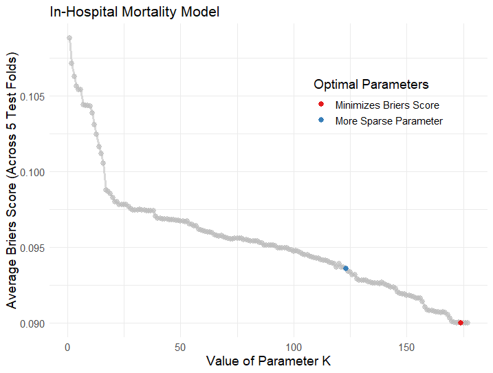

## Mortality (Covariate Importance)

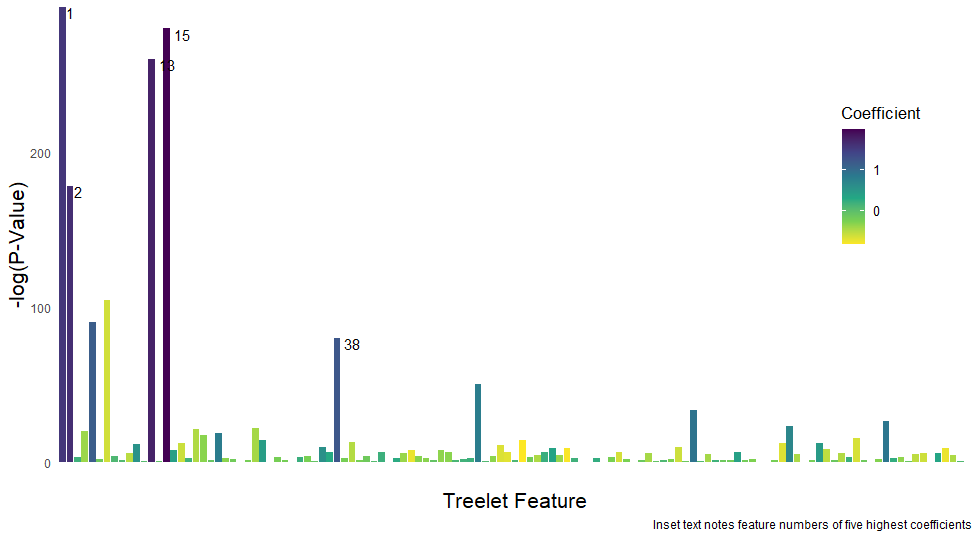

## Mortality (ROC Curves)

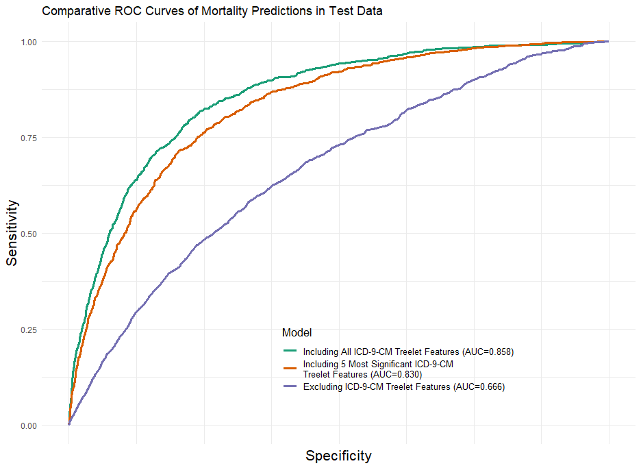

## Mortality (Predicted Probabilities)

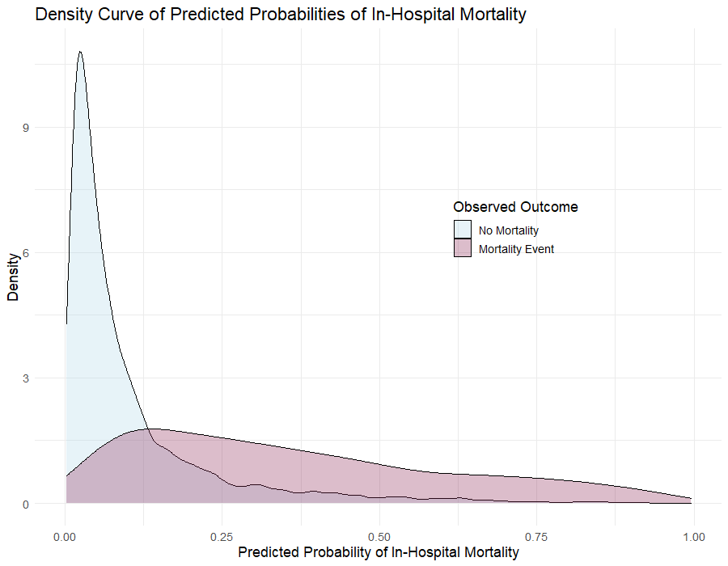

## Mortality (Summary)

- Treelet reduction (and cross-validation) did *not* yield a sparse feature space
  - \(K=123\) dimensions retained loadings from all 178 diagnosis codes

| **Model** | **Test AUC** |
| --- | --- |
| Including All Treelet Features | 0.858 |
| Including 5 Most-Significant Treelet Features | 0.830 |
| Excluding Treelet Features | 0.666 |

## In-Hospital Mortality Hospital Re-Admission Length of Stay

## Readmission (Cross-Validation)

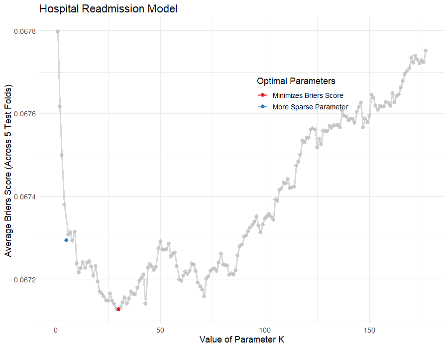

## Readmission (Covariate Importance)

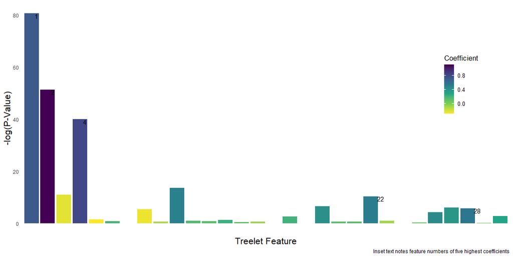

## Readmission (ROC Curves)

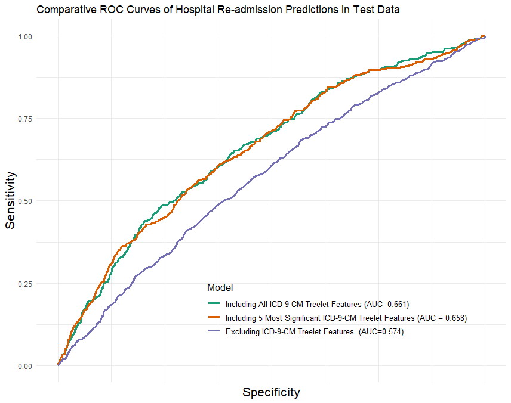

## Readmission (Predicted Probabilities)

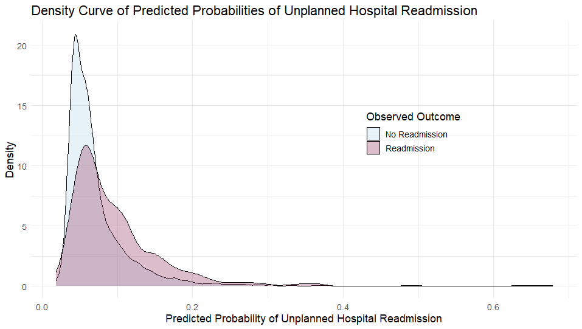

## Readmission (Summary)

- Treelet improved performance but still presented only limited discrimination of hospital re-admission
  - While cross-validation reduced our 178 diagnosis codes covariates into \(K=30\) variables, we again retained loadings from all codes

| Model | Test AUC |
| --- | --- |
| Including All Treelet Features | 0.661 |
| Including 5 Most-Significant Treelet Features | 0.658 |
| Excluding Treelet Features | 0.574 |

## In-Hospital Mortality Hospital Re-admission Length of Stay

## Length of Stay (Cross-Validation)

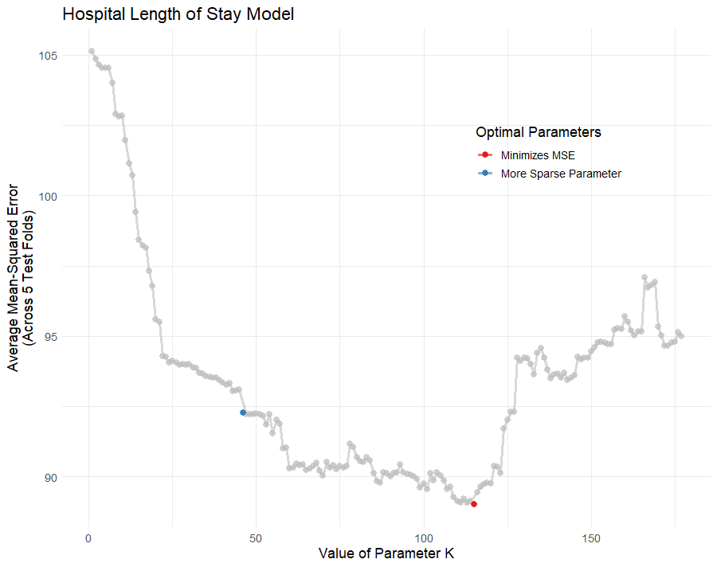

## Length of Stay (Covariate Importance)

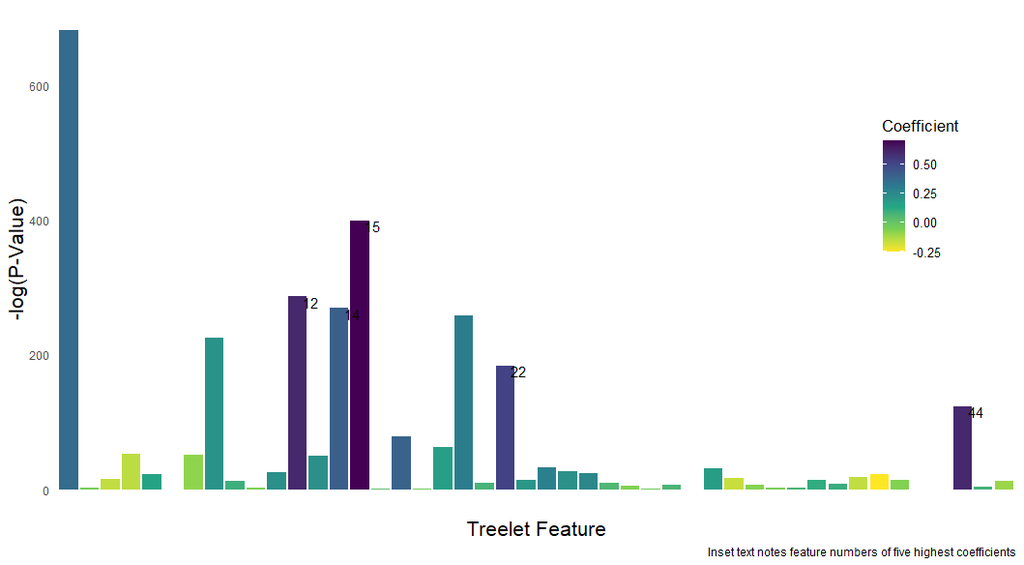

## Length of Stay (Performance by Included Features)

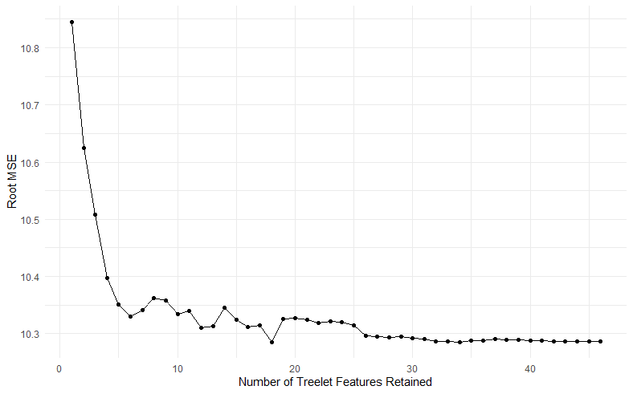

## Length of Stay (Predicted Values)

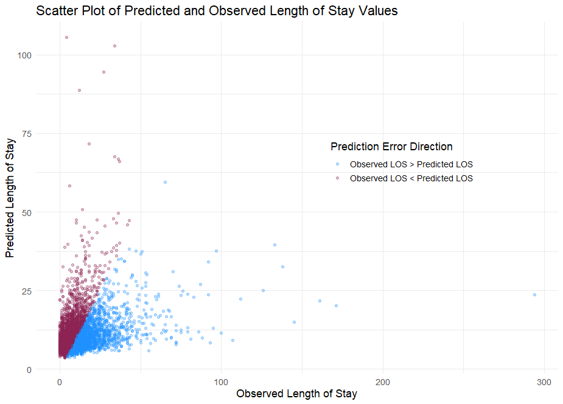

## Length of Stay (Summary)

- Treelet identified a reduced dimensionality and a sparse feature set
  - The retained \(K=46\) variables from our treelet model including loadings from 107 of our 178 ICD-9-CM diagnosis codes

| Model | Test RMSE |
| --- | --- |
| Including All Treelet Features | 10.29 |
| Including 5 Most-Significant Treelet Features | 10.35 |
| Excluding Treelet Features | 11.09 |

## Model Comparisons

## Comparative Model Results

| *Model* | **Mortality*** | **Readmission*** | **Length of Stay**** |
| --- | --- | --- | --- |
| All Treelet Features | 0.858 | 0.661 | 10.29 |
| Top 5 Treelet Features | 0.830 | 0.658 | 10.35 |
| Lasso | 0.868 | 0.669 | 9.61 |
| PCA | 0.860 | 0.667 | 10.24 |
| All ICD Codes | 0.867 | 0.667 | 11.75 |
| Charlson | 0.632 | 0.502 | 13.48 |
| Elixhauser | 0.615 | 0.513 | 13.49 |

* *AUC*; ** *RMSE*

## Implications & Conclusions

## Objectives (Revisited)

- **Primary Objective**: Transform a large number of ICD-9-CM diagnosis codes into a sparse set of features using *treelet dimension reduction*, and apply this new feature space towards the *prediction of clinical outcomes* of in-hospital mortality, unplanned hospital re-admission, and hospital length of stay.
- **Public Health Significance**: The presented work leverages a large, publicly accessible database of critical care admissions and generates useful predictive models of clinical outcomes using only patient demographic and comorbidity diagnosis information.

## Summary

- ICD-9-CM diagnosis codes improve predictive performance of in-hospital mortality, but remain limited in their ability to predict hospital length of stay and re-admission
- Additional information (e.g. patient discharge disposition, social determinants of health, patient environment data) may be necessary to adequately predict post-discharge outcomes
- Treelet dimension reduction reduces the number of retained covariates in our models but does not outperform PCA, LASSO

## References

- Awad, A., Bader–El–Den, M., & McNicholas, J. (2017). Patient length of stay and mortality prediction: A survey. Health Services Management Research, 30(2), 105–120. https://doi.org/10.1177/0951484817696212
- Lee, A. B., Nadler, B., & Wasserman, L. (2008). Treelets—An adaptive multi-scale basis for sparse unordered data. The Annals of Applied Statistics, 2(2), 435–471. https://doi.org/10.1214/07-AOAS137
- Harrell, F. E. (2001). Regression Modeling Strategies: With Applications to Linear Models, Logistic Regression, and Survival Analysis (Updated September 4, 2020). Springer Science & Business Media.
- Hastie, T., Tibshirani, R., & Friedman, J. (2017). The Elements of Statistical Learning: Data Mining, Inference, and Prediction (Second Edition). Springer.
- MIMIC-III, a freely accessible critical care database. Johnson AEW, Pollard TJ, Shen L, Lehman L, Feng M, Ghassemi M, Moody B, Szolovits P, Celi LA, and Mark RG. Scientific Data (2016). DOI: 10.1038/sdata.2016.35. Available from: http://www.nature.com/articles/sdata201635

## Supplemental Slides

## Probability Curves

## Mortality

**Retaining only demographic predictors**

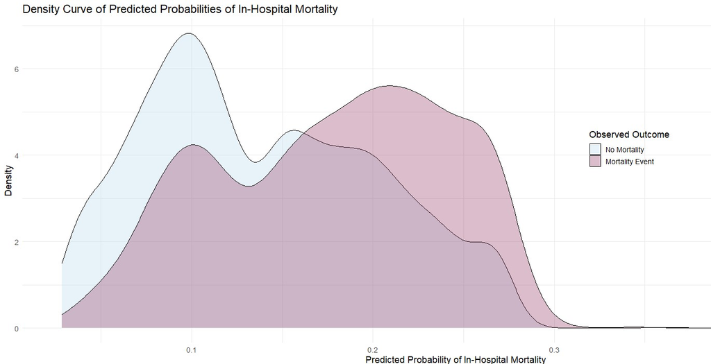

## Mortality

**Retaining demographic & treelet predictors**

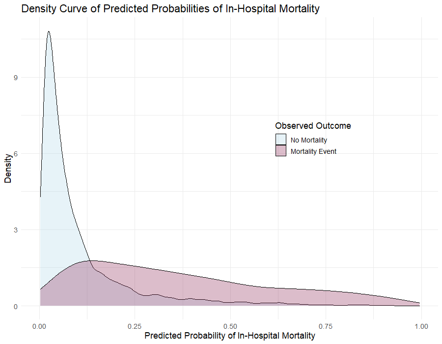

## Readmission

**Retaining only demographic predictors**

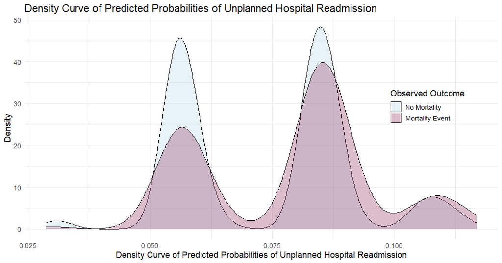

## Readmission

**Retaining demographic & treelet predictors**

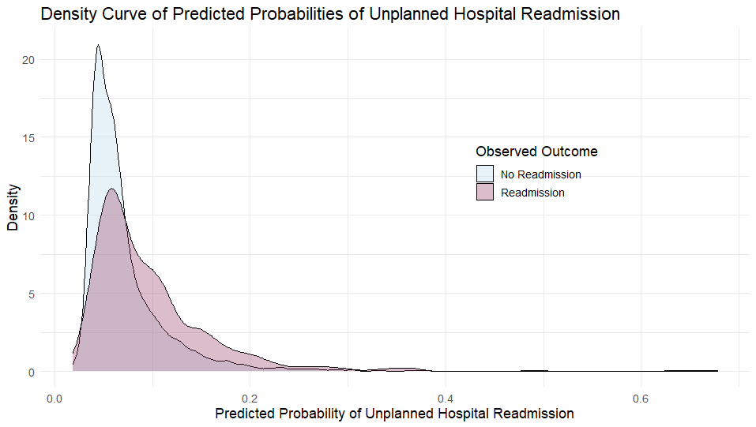

## Length of Stay

**Retaining only demographic predictors**

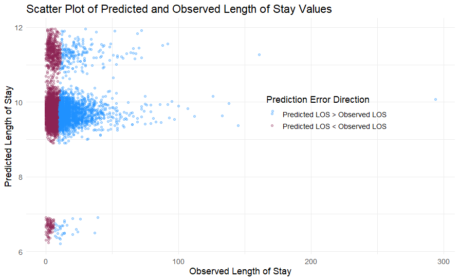

## Length of Stay

**Retaining demographic & treelet predictors**

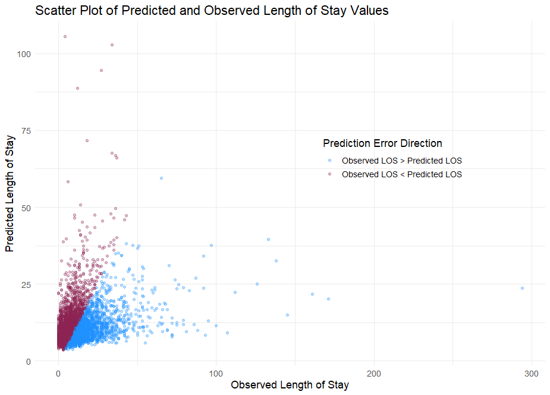

## Retained Diagnosis Codes

## Retained Diagnosis Codes

| Outcome | All Treelet Features | Top 5 Treelet Features | LASSO |
| --- | --- | --- | --- |
| Mortality | 178 | 38 | 170 |
| Hospital Re-admission | 178 | 178 | 48 |
| Length of Stay | 107 | 29 | 178 |

## Notable Treelet Features

## Mortality

[output not shown]

## Readmission

| ICD-9-CM Code | Treelet Feature | Loading | Description |
| --- | --- | --- | --- |
| 584.9 | Cluster 1 | 0.604 | Acute kidney failure NOS |
| 518.81 | Cluster 1 | 0.418 | Acute respiratry failure |
| 599.0 | Cluster 1 | 0.252 | Urin tract infection NOS |
| 705.4 | Cluster 2 | 0.491 | Chrnc hpt C wo hpat coma |
| 571.2 | Cluster 2 | 0.484 | Alcohol cirrhosis liver |
| 572.3 | Cluster 2 | 0.413 | Portal hypertension |
| 427.1 | Cluster 22 | 0.889 | Parox ventric tachycard |
| 425.4 | Cluster 22 | 0.406 | Prim cardiomyopathy NEC |
| 410.11 | Cluster 22 | 0.116 | AMI anterior wall, init |
| 357.2 | Cluster 4 | 0.573 | Neuropathy in diabetes |
| 403.91 | Cluster 4 | 0.494 | Hyp kid NOS w cr kid V |
| 250.60 | Cluster 4 | 0.469 | DMII neuro nt st uncntrl |

## Length of Stay

| ICD-9-CM Code | Treelet Feature | Loading | Description |
| --- | --- | --- | --- |
| 584.9 | Cluster 1 | 0.555 | Acute kidney failure NOS |
| 518.81 | Cluster 1 | 0.507 | Acute respiratry failure |
| 995.92 | Cluster 1 | 0.347 | Severe sepsis |
| 198.5 | Cluster 2 | 0.556 | Secondary malig neo bone |
| 197.7 | Cluster 2 | 0.539 | Second malig neo liver |
| 197.0 | Cluster 2 | 0.475 | Secondary malig neo lung |
| 263.9 | Cluster 22 | 1.000 | Protein-cal malnutr NOS |
| 585.9 | Cluster 4 | 0.708 | Chronic kidney dis NOS |
| 403.90 | Cluster 4 | 0.703 | Hy kid NOS w cr kid I-IV |
| 585.3 | Cluster 4 | 0.067 | Chr kidney dis stage III |

## Additional Comparative Models (Treelet & ICD Features)

## Comparative Models (Treelet & ICD Only)

| Outcome | Treelet (All Features) | ICD Codes (All Features) | Treelet (5 Features) | ICD Codes (Top 5 Features) |
| --- | --- | --- | --- | --- |
| Mortality | 0.858 | 0.867 | 0.830 | 0.851 |
| Readmission | 0.661 | 0.667 | 0.658 | 0.667 |
| Length of Stay | 10.29 | 11.75 | 10.35 | 11.22 |

## Patient Demographic Model Results

## Mortality (Model Results)

| Predictor | \(\beta\) | 95% Confidence Interval | P-Value |
| --- | --- | --- | --- |
| Intercept Term | -5.021 | [-5.371, -4.671] | <0.001 |
| Age | 0.038 | [0.035, 0.042] | <0.001 |
| Sex (Male) | -0.118 | [-0.198, -0.037] | 0.004 |
| **Insurance** |  |  |  |
| Medicaid | 0.178 | [-0.140, 0.497] | 0.273 |
| Medicare | 0.328 | [0.029, 0.627] | 0.032 |
| Private Insurance | 0.103 | [-0.191, 0.397] | 0.491 |
| Self-Pay | 1.174 | [0.762, 1.586] | <0.001 |

**Test Model Performance: Brier Score = 0.0917; AUC = 0.858**

## Readmission (Final Model Results)

| Predictor | \(\beta\) | 95% Confidence Interval | P-Value |
| --- | --- | --- | --- |
| Intercept Term | -3.137 | [-3.490, 2.783] | <0.001 |
| Age | 0.002 | [-0.002, 0.007] | 0.455 |
| Sex (Male) | 0.039 | [-0.142, 0.064] | 0.281 |
| **Insurance** |  |  |  |
| Medicaid | 0.484 | [0.162, 0.806] | 0.003 |
| Medicare | 0.310 | [0.005, 0.625] | 0.053 |
| Private Insurance | 0.033 | [-0.336, 0.271] | 0.833 |
| Self-Pay | -0.608 | [-1.278, 0.061] | 0.075 |

**Test Model Performance: Brier Score = 0.0681; AUC = 0.661**

## Length of Stay (Final Model Results)

| Predictor | \(\beta\) | 95% Confidence Interval | P-Value |
| --- | --- | --- | --- |
| Intercept Term | 2.001 | [1.942, 2.061] | <0.001 |
| Age | -0.002 | [-0.003, 0.002] | <0.001 |
| Sex (Male) | 0.053 | [0.035, 0.071] | <0.001 |
| Insurance |  |  |  |
| Medicaid | 0.114 | [0.058, 0.171] | <0.001 |
| Medicare | 0.048 | [-0.006, 0.101] | 0.079 |
| Private Insurance | 0.039 | [-0.12, 0.090] | 0.133 |
| Self-Pay | -0.318 | [-0.407, -0.229] | <0.001 |

**Test Model Performance: RMSE = 10.29**